# Introducción a distribuciones de probabilidad

Ramon Ceballos

9/2/2021

# **Distribución Normal o Campana de Gauss**

## 1. Conceptos teóricos y matemáticos

Una v.a. $X$ tiene distribución normal o gaussiana de parámetros $\mu$ (media) y $\sigma$ (desviación típica), **$X\sim\mathcal{N}(\mu,\sigma)$** si su función de densidad es:

$$f_X(x)=\frac{1}{\sqrt{2\pi}\sigma}e^{-\frac{(x-\mu)^2}{2\sigma^2}}\quad \forall x\in\mathbb{R}$$

La gráfica de $f_X$ es conocida como la **Campana de Gauss**.

Cuando $\mu = 0$ y $\sigma = 1$, diremos que la v.a. $X$ (distribución normal) es **estándar** y la indicaremos usualmente como **$Z$**, la cual tendrá la función de densidad siguiente:

$$f_Z(z)=\frac{1}{\sqrt{2\pi}}e^{-\frac{z^2}{2}}\quad \forall z\in\mathbb{R}$$

La integral de la función de densidad de una distribución normal estándar dará valor 1.

La esperanza y la varianza de una Distribución Normal vienen definidas a continuación.

- **Esperanza** $E(X) = \mu$
- **Varianza** $Var(X) = \sigma^2$

En particular, si $Z$ sigue una distribución estándar, entonces:

- **Esperanza** $E(X) = 0$
- **Varianza** $Var(X) = 1$

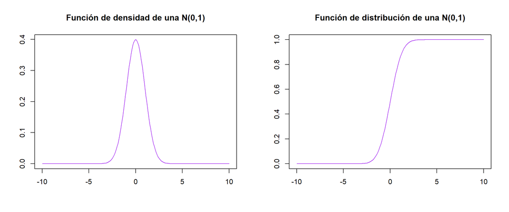

```r
par(mfrow = c(1,2))

#valores de x
z_scores <- seq(-10, 10, by = .1)

#probabilidad de los valores x según una normal
dvalues <- dnorm(z_scores)

plot(z_scores,
     dvalues,
     ylab = "",
     xlab= "",
     type = "l",
     col = "purple",
     main = "Función de densidad de una N(0,1)")


dvalues <- pnorm(z_scores)

plot(z_scores, dvalues,
     ylab = "",
     xlab= "",
     type = "l",
     col = "purple",
     main = "Función de distribución de una N(0,1)", ylim = c(0,1))
```

```r
par(mfrow = c(1,1))
```

La mayoría de factores de la vida real suele distribuirse según una campana de Gauss. Es por ello que esta distribución es muy famosa.

## 2. Distribución Normal en `R` y `Python`

El código de la distribución Normal:

- En **`R`** tenemos las funciones del paquete `stats`: **`dnorm(x, mean, sd), pnorm(q, mean, sd), qnorm(p, mean, sd), rnorm(n, mean, sd)`** donde `mean` es la media y `sd` es la desviación estándar de la normal $N(\mu, \sigma)$.
- En **`Python`** tenemos las funciones del paquete **`scipy.stats.normal`**: **`pdf(k, mu, scale), cdf(k, mu, scale), ppf(q, mu, scale), rvs(n, mu, scale)`** donde `mu` es la media y `scale` es la desviación estándar de la normal $N(\mu, \sigma)$.

Si a la hora de llamar a alguna de las 4 funciones siguientes: `dnorm`, `pnorm`, `qnorm` o `rnorm` no especificásemos los parámetros de la media ni la desviación típica, R entiende que se trata de la normal estándar: la $\mathcal{N}(0,1)$.

Es decir, R interpreta $\mu = 0$ y $\sigma = 1$.

En Python ocurre exactamente lo mismo.

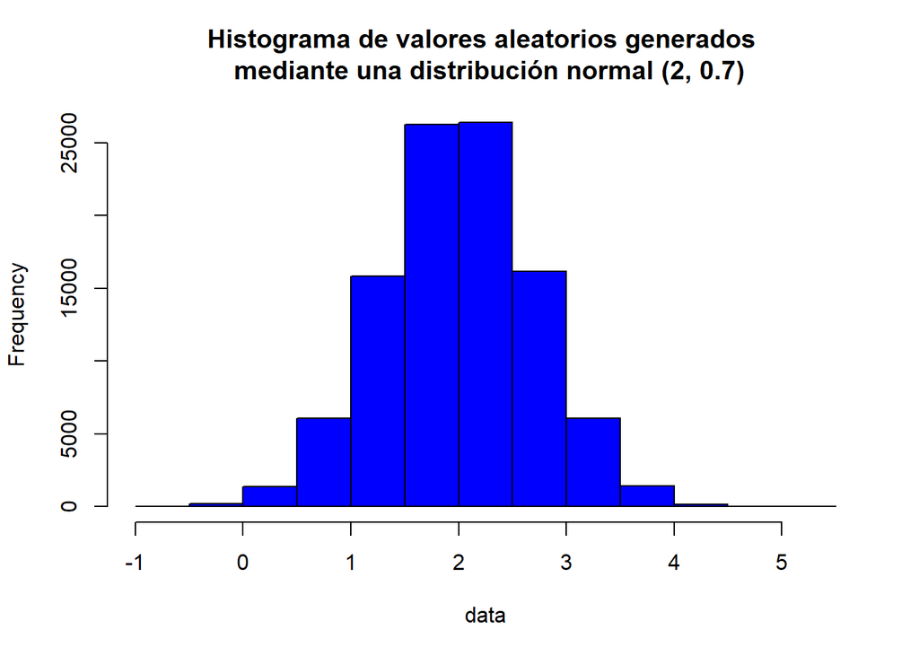

```r
rnorm(100000, mean=2, sd=0.7) -> data
hist(data,
     main="Histograma de valores aleatorios generados \n mediante una distribución normal (2, 0.7)",
     col="blue")
```

## 3. Estandarización de una variable aleatoria normal

**Estandarización de una v.a. normal.** Si $X$ es una v.a. $\mathcal{N}(\mu,\sigma)$, entonces:
$$Z=\frac{X-\mu}{\sigma}\sim\mathcal{N}(0,1)$$

Es decir, al restarle $\mu$ y dividirlo entre $\sigma$, la v.a. de dicha distribución normal pasará a ser una distribución normal estándar (**$Z$**).

Las probabilidades de una normal estándar $Z$ determinan las de cualquier $X$ de tipo $\mathcal{N}(\mu,\sigma)$:

$$p(X\le x)=p\left(\frac{X-\mu}{\sigma}\le\frac{x-\mu}{\sigma}\right)=p\left(Z\le\frac{x-\mu}{\sigma}\right)$$

En esta expresión, p(X) refiere a la probabilidad general de un distribución normal, y p(x) a dicha probabilidad pero de un nº cualquiera dentro de la normal. Si hacemos la estandarización, para el primer caso, nos queda la probabiildad de un distribución normal estándar($Z$), y para el segundo caso, son una serie de nºs.

$F_Z$ (la función de distribución) no tiene expresión teórica conocida, ya que carece de una primitiva la integral.

Por ello, durante años se aproximó por polinomios, para obtener la aproximación de $F_Z$.

Se puede calcular con cualquier programa, como por ejemplo R, o bien a mano utilizando las [tablas de la $\mathcal{N}(0,1)$](https://github.com/joanby/r-basic/blob/master/teoria/TablaNormal.pdf).

Con las tablas se pueden calcular tanto probabilidades como cuantiles.

**Ejemplo de estandarización**

La media de los pesos de 500 estudiantes de una clase universitaria es de 75 kg con una desviación típica de 4 kg. Partiremos de una Normal del tipo $X = \mathcal{N}(75,4)$.

Suponiendo que los pesos se distribuyen normalmente, hallar cuantos estudiantes pesan:

1. **Entre 65 kg y 80 kg**

En este caso tenemos lo siguiente:
$$p(65\le X\le 80) = p(X\le 80) - p(X\ge 65)$$

Ahora estandarizamos dicha expresión:
$$p(65\le X\le 80) = p\left(\frac {X-\mu}{\sigma}\le \frac {80-75}{4}\right) - p\left(\frac {X-\mu}{\sigma}\le \frac {65-75}{4}\right)$$

Denotando $Z = \frac {X-\mu}{\sigma}$ entonces obtenemos:
$$(65\le X\le 80) = p(Z \le 1.25) - p(Z \le -2.5)$$

Ahora empleamos las tablas de la Distribución Normal estándar y sustituimos:
$$(65\le X\le 80) = 0.8944 - 0.0062
= 0.8882$$

El 88.82% de los alumnos están en este intervalo de peso.

2. **Más de 90 kg**

En este caso:
$$p(X\ge 90) = 1 - p(X\le 90) = 1 - p\left(\frac{X-\mu}{\sigma} \le \frac{90-75}{4}\right)$$

Finalmente se obtiene:
$$p(X\ge 90) = 1-p(Z\le 3.75) = 1 - 0.9999 = 0.0001$$

El 0.01% de los estudiantes tienen un peso superior a 90kg.

```r
#Lo mismo en R
mu = 75
sigma = 4
x=90
#Estandarizamos
x_n=(x-mu)/sigma

p_90 = round(1 - pnorm((x_n)),6)
sprintf("La probabilidad será: %s", p_90)
```

```
## [1] "La probabilidad será: 8.8e-05"
```

```r
sprintf("El %s por ciento de los estudiantes tendrán un peso superior a 90 kg", p_90*100)
```

```
## [1] "El 0.0088 por ciento de los estudiantes tendrán un peso superior a 90 kg"
```

3. **69 kg**

En teoría debe de ser 0.

```r
x=69
x_n= (69-mu)/sigma
x_n
```

```
## [1] -1.5
```

```r
dnorm(x_n)
```

```
## [1] 0.1295176
```

4. **Menos de 70 kg**

```r
pnorm(70,75,4)
```

```
## [1] 0.1056498
```

```r
-5/4
```

```
## [1] -1.25
```

5. **69 kg o más**

```r
1 - pnorm(69,75,4)
```

```
## [1] 0.9331928
```

## 4. Empleo de Tablas de la Distribución Normal Estándar($\mathcal{N}(0 ,1)$)

Mírate el video 173 de la sección 16 en Udemy, dentro del cursos de estadística descriptiva.